# Fundamentos de Data Science I

### Projeto 2: análise do caso Titanic

#### Aluno: Giulio Cesare Mastrocinque Santo

##### Nome do Arquivo .csv: "titanic-data-6.csv" (dado pelo curso)

Neste projeto procura-se realizar uma análise de dados completa dentro do escopo da estatística descritiva. Para tanto, a análise será dividida nas seguintes etapas:

**Etapa 1:** questionamentos  
**Etapa 2:** preparação dos dados (wrangle)  
**Etapa 3:** exploração e análise (explore)  
**Etapa 4:** conclusões  
**Etapa 5:** comunicação dos resultados

Vale ressaltar que a Etapa 5 é o resultado desta documentação.

## Etapa 1: Questionamentos

Neste projeto estamos trabalhando com um conjunto de dados que dizem respeito ao caso Titanic.

"O RMS Titanic foi um navio de passageiros britânico operado pela White Star Line e construído pelos estaleiros da Harland and Wolff em Belfast. Foi a segunda embarcação da Classe Olympic de transatlânticos depois do RMS Olympic e seguido pelo HMHS Britannic.  
[...]  
A embarcação partiu em sua viagem inaugural de Southampton para Nova Iorque em 10 de abril de 1912, no caminho passando em Cherbourg-Octeville na França e por Queenstown na Irlanda. Ele colidiu com um iceberg às 23h40min do dia 14 de abril e afundou na madrugada do dia seguinte com mais de 1 500 pessoas a bordo, sendo um dos maiores desastres marítimos em tempos de paz de toda a história. " (Fonte: Wikipédia, a enciclopédia livre.)

O conjuto de dados que serão utilizados foi extraído de https://www.kaggle.com/c/titanic/data e pode ser resumido abaixo:

| Variable | Definition | Key |
| --- | --- | --- |
| survival | Survival | 0 = No, 1 = Yes |
| pclass | Ticket class | 1 = 1st, 2 = 2nd, 3 = 3rd |
| sex | Sex |  |
| Age | Age in years |  |
| sibsp | # of siblings / spouses aboard the Titanic |  |
| parch | # of parents / children aboard the Titanic |  |
| ticket | Ticket number |  |
| fare | Passenger fare |  |
| cabin | Cabin number |  |
| embarked | Port of Embarkation | C = Cherbourg, Q = Queenstown, S = Southampton |

Todos aqueles que já assistiram ao Filme "Titanic" de James Cameron sabem que uma das grande frustações do filme é o fato de os passageiros de renda inferior terem ficado presos nos andares mais baixos do navio. Este foi o caso de Leonardo di Caprio! Esse projeto permitirá enxergar melhor se isso de fato aconteceu!

Com base na tabela acima, perguntas relevantes que serão analisadas são:

```
 1. A idade das pessoas está relacionada ao número de sobreviventes? Por exemplo: pessoas mais velhas foram mais afetadas?

2. Pessoas com filhos foram mais afetadas pelo incidente? E casais e irmãos?

3. A classe econômica (primeira, segunda ou terceira classe) interferiu diretamente no número de sobreviventes, ou seja, pessoas que estavam em classe mais luxuosas tiveram mais chances de sobreviver?

4. O preço da passagem está relacionado à chance de sobrevivência? Em outras palavras, que características tinham as passagens de passageiros que sobreviveram?
```

## Etapa 2: Preparação dos Dados (Wrangle)

Nesta etapa reuniremos os dados mais relevantes para responder às perguntas formuladas e faremos um tratamento deles para explorá-los de forma adequada.

```python
#Importação dos pacotes que serão utilizados
import numpy as np
import pandas as pd
import matplotlib.pyplot as plt
%matplotlib inline
import seaborn as sns
#Gráficos em 3D
from mpl_toolkits.mplot3d import Axes3D

sns.set_style('darkgrid') #Configuração para gráficos
pd.options.mode.chained_assignment = None

#Leitura do arquivo csv com as informações mostradas na tabela
titanic_df = pd.read_csv('titanic-data-6.csv')


#Definição das Funções que Serão Mais Utilizadas:
def num_row_col(df,name):
    """
    Calcula o número de Amostras e de Colunas de um Dataframe de nome "name"
    Parameters:
    df: DataFrame a ser analisado
    name: nome do DataFrame
    """
    print("Número de Amostras e Colunas em {}: {} Amostras e {} Colunas".format(name,df.shape[0],df.shape[1]))

def num_repeated_rows(df,name):
    """
    Calcula o número de Linhas Duplicatadas de um Dataframe de nome "name"
    Parameters:
    df: DataFrame a ser analisado
    name: nome do DataFrame
    """
    print("Número de Linhas repetidas em {}: {}".format(name,sum(df.duplicated())))

def num_null_col(df,name):
    """
    Calcula que atributos tem valores nulos em um Dataframe de nome "name"
    Parameters:
    df: DataFrame a ser analisado
    name: nome do DataFrame
    """
    print('Atributos com Valores Ausentes em {}: {}'.format(name,df.columns[df.isnull().any()].values))
```

```python
#Vamos visualizar os dados que nós temos:
titanic_df.head()
```

|  | PassengerId | Survived | Pclass | Name | Sex | Age | SibSp | Parch | Ticket | Fare | Cabin | Embarked |
| --- | --- | --- | --- | --- | --- | --- | --- | --- | --- | --- | --- | --- |
| 0 | 1 | 0 | 3 | Braund, Mr. Owen Harris | male | 22.0 | 1 | 0 | A/5 21171 | 7.2500 | NaN | S |
| 1 | 2 | 1 | 1 | Cumings, Mrs. John Bradley (Florence Briggs Th... | female | 38.0 | 1 | 0 | PC 17599 | 71.2833 | C85 | C |
| 2 | 3 | 1 | 3 | Heikkinen, Miss. Laina | female | 26.0 | 0 | 0 | STON/O2. 3101282 | 7.9250 | NaN | S |
| 3 | 4 | 1 | 1 | Futrelle, Mrs. Jacques Heath (Lily May Peel) | female | 35.0 | 1 | 0 | 113803 | 53.1000 | C123 | S |
| 4 | 5 | 0 | 3 | Allen, Mr. William Henry | male | 35.0 | 0 | 0 | 373450 | 8.0500 | NaN | S |

```python
#Primeiramente, vamos trabalhar apenas com as características que nos interessam
#para isso, selecionamos apenas as colunas ['Survived',Pclass','Sex','Age,'SibSp','Parch','Fare']
custom_df = titanic_df.iloc[:,np.r_[1,2,4,5,6,7,9]]

#agora editamos os nomes das colunas, deixando-as com letra minúscula
custom_df.columns = map(str.lower, custom_df.columns)

#Verificando o Número de Amostras e Características
num_row_col(custom_df,"custom_df")

#Verificando se existem dados repetidos
num_repeated_rows(custom_df,"custom_df")

#Verificando Atributos com Valores Ausentes
num_null_col(custom_df,"custom_df")

#Verificando a base editada
custom_df.head()
```

```
Número de Amostras e Colunas em custom_df: 891 Amostras e 7 Colunas
Número de Linhas repetidas em custom_df: 114
Atributos com Valores Ausentes em custom_df: ['age']
```

|  | survived | pclass | sex | age | sibsp | parch | fare |
| --- | --- | --- | --- | --- | --- | --- | --- |
| 0 | 0 | 3 | male | 22.0 | 1 | 0 | 7.2500 |
| 1 | 1 | 1 | female | 38.0 | 1 | 0 | 71.2833 |
| 2 | 1 | 3 | female | 26.0 | 0 | 0 | 7.9250 |
| 3 | 1 | 1 | female | 35.0 | 1 | 0 | 53.1000 |
| 4 | 0 | 3 | male | 35.0 | 0 | 0 | 8.0500 |

A tabela acima mostra um dataframe já um pouco customizado. Os próximos passos serão remover valores nulos e duplicados.

Caso eliminemos todos os valores nulos, ficaremos com uma amostra muito pequena. Portanto, como os valores nulos estão apenas no atributo 'age', podemos trabalhar com dois DataFrames. Em uma amostra que contenha valores nulos (NaN) em 'age' existem também valores úteis de outras características e que podem ser aproveitados. Portanto, vamos criar 2 dataframes: 1 retirando todos os valores nulos e outro não excluindo valor algum.

- custom_age_df: retira-se os valores nulos de 'age' para trabalhar com essa característica especificamente.
- custom_df: mantém todos os valores para aproveitar as demais características que não possuem valores nulos.

```python
#Removendo Linhas com valores faltando apenas da coluna 'age' (nesse casos seria o mesmo que excluir todos os NaN)
#O trecho abaixo foi retirado de "https://stackoverflow.com/questions/36370839/better-way-to-drop-nan-rows-in-pandas"
custom_age_df = custom_df.dropna(subset=['age'])

#Precisamos corrigir o index após exclusão das linhas
#O trecho de código abaixo foi retirado de
#https://stackoverflow.com/questions/40755680/how-to-reset-index-pandas-dataframe-after-dropna-pandas-dataframe
custom_age_df.reset_index(drop=True, inplace=True)

#Vamos verificar que apenas custom_df tem valores nulos (que estão na coluna 'age')
num_null_col(custom_df,"custom_df")
num_null_col(custom_age_df,"custom_age_df")
print("\n")

#Verificando Número de Linhas e Colunas dos Novos DataFrames
num_row_col(custom_df,"custom_df")
num_row_col(custom_age_df,"custom_age_df")
print("\n")

#Verificando Número de Duplicatas
num_repeated_rows(custom_df,"custom_df")
num_repeated_rows(custom_age_df,"custom_age_df")
print("\n")

#Descartando Duplicatas
custom_df.drop_duplicates(inplace=True)
custom_age_df.drop_duplicates(inplace=True)

#Verificando Novamente o Número de Duplicatas
print("Nova Verificação de Duplicatas Após Remoção: \n")
num_repeated_rows(custom_df,"custom_df")
num_repeated_rows(custom_age_df,"custom_age_df")
print("\n")

#Verificando Número de Amostras e Características Novamente
print("Verificando Novamente as Características Após Remoção\n")
num_row_col(custom_df,"custom_df")
num_row_col(custom_age_df,"custom_age_df")
```

```
Atributos com Valores Ausentes em custom_df: ['age']
Atributos com Valores Ausentes em custom_age_df: []


Número de Amostras e Colunas em custom_df: 891 Amostras e 7 Colunas
Número de Amostras e Colunas em custom_age_df: 714 Amostras e 7 Colunas


Número de Linhas repetidas em custom_df: 114
Número de Linhas repetidas em custom_age_df: 40


Nova Verificação de Duplicatas Após Remoção:

Número de Linhas repetidas em custom_df: 0
Número de Linhas repetidas em custom_age_df: 0


Verificando Novamente as Características Após Remoção

Número de Amostras e Colunas em custom_df: 777 Amostras e 7 Colunas
Número de Amostras e Colunas em custom_age_df: 674 Amostras e 7 Colunas
```

A seguir, podemos inspecionar e ajustar os tipos de dados

```python
#Agora avaliamos os tipos de dados. Podemos usar custom_df para isso (que contém todos os dados)
for column in custom_df.columns:
    print("Column {} -> Data Type: {}".format(column,type(custom_df[column][1])))
```

```
Column survived -> Data Type: <class 'numpy.int64'>
Column pclass -> Data Type: <class 'numpy.int64'>
Column sex -> Data Type: <class 'str'>
Column age -> Data Type: <class 'numpy.float64'>
Column sibsp -> Data Type: <class 'numpy.int64'>
Column parch -> Data Type: <class 'numpy.int64'>
Column fare -> Data Type: <class 'numpy.float64'>
```

Os tipos de dados já estão adequados, de forma que não precisamos alterar nada.

## Etapa 3: Explorando e Analisando os Dados

Nesta etapa será realizada a análise dos dados a fim de responder as perguntas elaboradas.

```python
#Declaração de Funções que Serão Utilizadas nas Análises

def age_analysis(df):
    """
    Realiza a Análise da Idade. Verifica a existência de Correlação entre idade e sobreviventes. Apresenta
    gráfico de correlação de distribuição
    Parameters:
        df: DataFrame a ser analisado
    """

    #Plot de Gráfico de Correlação Entre Idade e Sobrevivência
    plt.scatter(df['age'],df['survived'],color='orange');
    plt.title('Sobreviventes x Idade');
    plt.xlabel('Idade');
    plt.ylabel('Sobreviveu?');

    #Criando Um DataFrame para os sobreviventes
    survived = df.query('survived == "1"')

    #Criando um DataFrame para os não sobreviventes
    not_survived = df.query('survived == "0"')

    #Verificando Idade Média dos Sobreviventes
    print("A idade média dos Sobreviventes foi de {} anos".format(survived['age'].mean()))
    print("A idade média dos Não Sobreviventes foi de {} anos".format(not_survived['age'].mean()))

    #Traçando Distribuição para a idade dos sobreviventes
    #survived['age'].plot(kind='hist', figsize=(4,4), title='Distribuição da Idade dos Sobreviventes');
    plt.figure()
    sns.kdeplot(survived['age'], shade=True, legend = False);
    plt.xlabel('Idade');
    plt.title('Distribuição da Variável Idade Entre os Sobreviventes')

    #Traçando Distribuição para a idade dos não sobreviventes
    #not_survived['age'].plot(kind='hist', figsize=(4,4), title='Distribuição da Idade dos Não Sobreviventes');
    plt.figure()
    ax = sns.kdeplot(not_survived['age'], shade=True, legend = False);
    plt.xlabel('Idade');
    plt.title('Distribuição da Variável Idade Entre os Não Sobreviventes')

    #Traçando um pointplot para visualizar as médias dos sobreviventes e dos não sobreviventes graficamente
    plt.figure()
    sns.pointplot(x="survived", y="age", data=df, linestyles=["--"], color='g');
    plt.xticks([0,1],['Não','Sim'])
    plt.xlabel('Sobreviveu?')
    plt.ylabel('Idade Média')
    plt.title('Média de Idade dos Sobreviventes e dos Não Sobreviventes')

def relatives_analysis(df):
    """
    Realiza a Análise de Pais/Crianças e Irmãos/Casais. Verifica a existência de Correlações.
    Apresenta gráficos de correlação, gráficos de barras, countplots e cálculos de média.
    Parameters:
        df: DataFrame a ser analisado
    """
    #Criando Um DataFrame para os sobreviventes
    survived = df.query('survived == "1"')

    #Criando um DataFrame para os não sobreviventes
    not_survived = df.query('survived == "0"')

    #Número de Sobreviventes e Não Sobreviventes
    numb_surv = survived['parch'].count()
    numb_not_surv = not_survived['parch'].count()

    #Número de Pessoas com Mulheres ou Irmãos e Pais e Filhos Sobreviventes e Não Sobreviventes
    num_parch_surv = survived['parch'].count()
    num_sibsp_surv = survived['sibsp'].count()

    num_parch_not_surv = not_survived['parch'].count()
    num_sibsp_not_surv = not_survived['sibsp'].count()

    #Verificando Numero Médio dos Sobreviventes e dos Não Sobreviventes
    print("A Quantidade Média de Pais/Crianças Sobreviventes foi de: {} Pais/Crianças".format(
          survived['parch'].mean()))
    print("A Quantidade Média de Pais/Crianças Não Sobreviventes foi de: {} anos \n".format(
          not_survived['parch'].mean()))
    print("A Quantidade Média de Irmãos/Casais Sobreviventes foi de: {} Irmãos/Casais".format(
          survived['sibsp'].mean()))
    print("A Quantidade Média de Irmãos/Casais Não Sobreviventes foi de: {} Irmãos/Casais".format(
          not_survived['sibsp'].mean()))

    #Traçando gráfico de contagem para comparar número de sobreviventes e não sobreviventes entre Parentes
    plt.figure()
    sns.countplot(y="parch", hue="survived", data=df, palette="Greens_d");
    plt.xlabel('Número de Passageiros Com Essa Característica')
    plt.ylabel('Número de Pais/Crianças')
    plt.title('Número de Pais/Crianças que Sobreviveram ou Não')

    #Traçando gráfico de contagem para comparar número de sobreviventes e não sobreviventes entre Irmãos/Casais
    plt.figure()
    sns.countplot(y="sibsp", hue="survived", data=df, palette="Reds_d");
    plt.xlabel('Número de Passageiros Com Essa Característica')
    plt.ylabel('Número de Irmãos/Casais')
    plt.title('Número de Irmãos/Casais que Sobreviveram ou Não')

    #Gráficos de Barras com esses valores:
    #plt.bar([0,1],[survived['parch'].mean(),not_survived['parch'].mean()])
    plt.figure()
    sns.barplot(x='survived',y='parch',data=df)
    plt.xticks([0,1],['Não','Sim'])
    plt.xlabel('Sobreviveu?')
    plt.ylabel('Número Médio de Pais/Crianças')
    plt.title("Número Médio de Pais/Crianças Entre os Sobreviventes e Não Sobreviventes")

    plt.figure()
    #plt.bar([0,1],[survived['sibsp'].mean(),not_survived['sibsp'].mean()])
    sns.barplot(x='survived',y='sibsp',data=df)
    plt.xticks([0,1],['Não','Sim'])
    plt.xlabel('Sobreviveu?')
    plt.ylabel('Número Médio de Irmãos/Casais')
    plt.title("Número Médio de Irmãos/Casais Entre os Sobreviventes e Não Sobreviventes")

    #Verificando Correlações
    plt.figure()
    plt.scatter(df['parch'],df['survived'],color='orange');
    plt.title('Sobreviventes x Pais/Crianças');
    plt.xlabel('Número Pais/Crianças');
    plt.ylabel('Sobreviveu?');

    plt.figure()
    plt.scatter(df['sibsp'],df['survived'],color='orange');
    plt.title('Sobreviventes x Irmãos/Casais');
    plt.xlabel('Número Irmãos/Casais');
    plt.ylabel('Sobreviveu?');

def pclass_analysis(df):
    """
    Realiza a Análise das Classes econômicas. Verifica a existência de Correlações.
    Apresenta gráfico de barras comparando a taxa de sobrevivência por classe econômica.
    Parameters:
        df: DataFrame a ser analisado
    """
    #Definindo grupo de classes econômicas
    classes = df.groupby(['pclass','survived']).count()['sex']

    #Definindo DataFrames Sobreviventes e Não Sobreviventes
    survived = df.query("survived == '1'")
    not_survived = df.query("survived == '0'")

    #Definindo Número total de pessoas a bordo e a proporção por classe
    total_aboard = df['sex'].count()
    proportion = classes/total_aboard

    #Criando lista com proporção de sobreviventes e de não sobreviventes para cada uma das classes (1a, 2a, 3a)
    prop_survived = [proportion.values[1], proportion.values[3], proportion.values[5]]
    prop_not_survived = [proportion.values[0],proportion.values[2],proportion.values[4]]

    #Criando Índice Para o Gráfico de Barras
    ind = list(proportion.index.levels[0])
    ind = np.arange(len(ind))

    #Criando Gráfico de Barras Para Comparar Proporção de sobreviventes por classe econômica
    width = 0.35
    plt.bar(ind,prop_survived,width,color='r',alpha=.7,label='Proporção Sobreviventes')
    plt.bar(ind+width,prop_not_survived,width,color='w',alpha=.7,label='Proporção Não Sobreviventes')
    locations = ind+width/2
    labels = ['Primeira Classe', 'Segunda Classe', 'Terceira Classe']
    plt.xticks(locations,labels);
    plt.title("Proporção de Sobrevivência Por Classe Econômica")
    plt.xlabel("Classe Econômica")
    plt.ylabel("Proporção de Sobrevivência")
    plt.legend();

    #Criando Segundo Gráfico de Barras com Comparação mais Genérica e Agrupada
    plt.figure()
    sns.barplot(x="sex", y="survived", hue="pclass", data=df);
    plt.xticks([0,1],['Masculino','Feminino'])
    plt.title("Sobreviventes Por Sexo e Classe Econômica")
    plt.xlabel("Sexo")
    plt.ylabel("Sobreviveu?")


    #Descrição das Classes dos Sobreviventes
    print("Descrição da Classe dos Sobreviventes: \n")
    display(survived['pclass'].describe())

    #Descrição das Classes dos Não Sobreviventes
    print("Descrição da Classe dos Não Sobreviventes: \n")
    display(not_survived['pclass'].describe())

def fare_analysis(df):
    """
    Realiza a Análise dos preços das passagens. Verifica a existência de Correlações.
    Apresenta um boxplot para melhor visualizar como os preços se distribuem entre sobreviventes e não sobreviventes.
    Parameters:
        df: DataFrame a ser analisado
    """

    #Definindo grupo de Preços das passagens
    sns.factorplot(x="survived",y="fare", data=df, kind="box", size=6, aspect=.5);
    plt.xticks([0,1],['Não','Sim'])
    plt.xlabel('Sobreviveu?')
    plt.ylabel('Preço da Passagem')
    plt.title('Preço da Passagem em Função da Sobrevência')


    #Definindo DataFrames Sobreviventes e Não Sobreviventes
    survived = df.query('survived == "1"')
    not_survived = df.query('survived == "0"')

    #Avaliando a média dos preços das passagens das pessoas que sobreviveram e das que não sobreviveram
    print('Média do Valor da Passagem dos Passageiros que Sobreviveram: {} \n'.format(
          df.query('survived == "1"')['fare'].mean()))
    print('Média do Valor da Passagem dos Passageiros que Não Sobreviveram: {}'.format(
          df.query('survived == "0"')['fare'].mean()))

    #Verificando Correlação entre Sobrevivência e Preço da Passagem
    plt.figure()
    plt.scatter(df['fare'],df['survived'],color='orange');
    plt.title('Preço das Passagens em Função da Sobrevivência');
    plt.xlabel('Preço da Passagem');
    plt.ylabel('Sobreviveu?');

    #Verificando Correlação entre Preço da Passagem e Classe Econômica
    plt.figure()
    plt.scatter(df['fare'],df['pclass'],color='orange');
    plt.title('Preço das Passagens em Função da Classe Econômica');
    plt.xlabel('Preço da Passagem');
    plt.ylabel('Classe Econômica');

    #Vamos traçar um scatter plot para três variáveis (Fonte: https://python-graph-gallery.com/370-3d-scatterplot/)
    fig = plt.figure()
    ax = Axes3D(fig)
    ax.scatter(df['pclass'], df['fare'], df['survived'],c='skyblue')
    ax.set_xlabel('Classe Econômica')
    ax.set_ylabel('Preço da Passagem')
    ax.set_zlabel('Sobreviveu?')
    plt.title("Correlação Entre Preço da Passagem, Classe Econômica e Sobrevivência")
    ax.invert_zaxis()
    plt.show()
```

#### Pergunta 1: A idade das pessoas está relacionada ao número de sobreviventes? Por exemplo: pessoas mais velhas foram mais afetadas?

Para responder a essa pergunta, podemos considerar os seguintes fatores:

```
 - As variáveis Idade e Sobreviventes estão correlacionadas?
 - Qual era a idade média dos sobreviventes? E dos não sobreviventes?
```

```
A idade média dos Sobreviventes foi de 28.361418439716314 anos
A idade média dos Não Sobreviventes foi de 30.868622448979593 anos
```

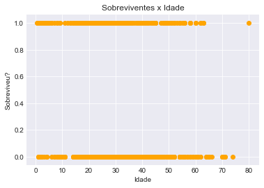

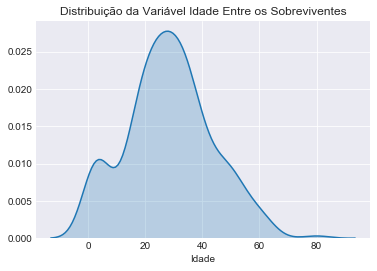

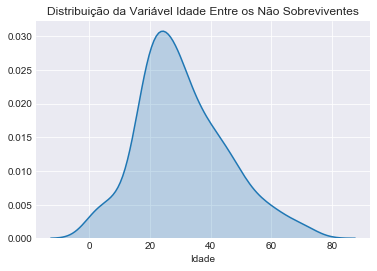

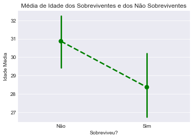

```python
age_analysis(custom_age_df)
```

A análise acima mostra que a média de idade das pessoas que sobreviveram é próxima à média de idade das pessoas que não sobreviveram ao acidente. Entretanto, parece existir uma tendência de aumento de idade entre os não sobreviventes. Os diagramas de dispersão mostram, por exemplo, que enquanto a Idade dos Sobreviventes possui uma distribuição mais próxima de uma normal, com média em torno de 28 anos, a Idade dos Não Sobreviventes possui uma distorção forte à direita que justamente corresponde a idades mais elevadas.

Analogamente, se analisarmos o "point plot" acima verificamos graficamente as médias de idade dos sobreviventes e dos não sobreviventes, em que a idade média dos não sobreviventes é um pouco maior.

O gráfico de correlação também sugere um deslocamento para a direita dos pontos que representam os não sobreviventes. Entretanto, como a diferença na média das distruibições de sobreviventes e não sobreviventes é pequena, não podemos concluir de forma definitiva que de fato pessoas mais velhas foram mais afetadas pelo acidente. Algum método de estatística inferencial deve ser utilizado (como um teste de hipótese) para chegarmos em conclusões mais precisas.

#### Pergunta 2: Pessoas com filhos foram mais afetadas pelo incidente? E casais e irmãos?

Para responder a essa pergunta, podemos considerar os seguintes fatores:

```
 - As variáveis parch e Sobreviventes estão correlacionadas? E as variáveis sibsp e sobreviventes?
 - Qual era a média de filhos dos sobreviventes? E dos não sobreviventes?
```

```
A Quantidade Média de Pais/Crianças Sobreviventes foi de: 0.48909657320872274 Pais/Crianças
A Quantidade Média de Pais/Crianças Não Sobreviventes foi de: 0.3706140350877193 anos

A Quantidade Média de Irmãos/Casais Sobreviventes foi de: 0.48286604361370716 Irmãos/Casais
A Quantidade Média de Irmãos/Casais Não Sobreviventes foi de: 0.5592105263157895 Irmãos/Casais
```

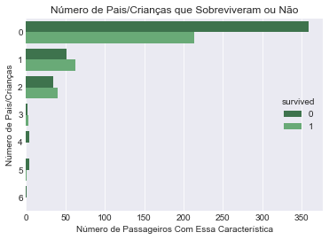

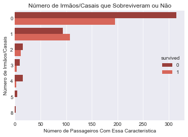

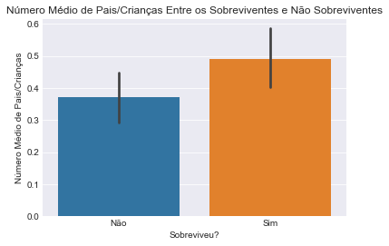

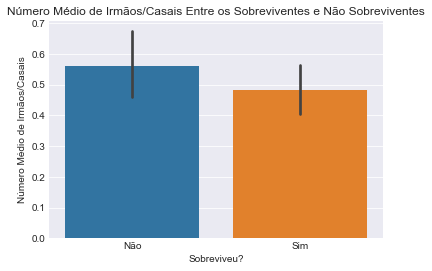

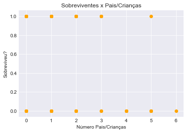

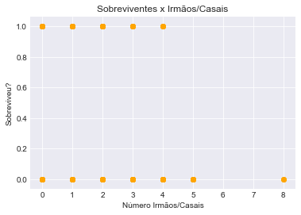

```python
#Calcula Numero de sobreviventes
relatives_analysis(custom_df)
```

Os gráficos de correlação acima mostram que existe uma tendência de menor chance de sobrevivência entre aqueles que estão com maior número de filhos ou parentes/casais. Ao mesmo tempo, os gráfico de barras com os valores médios não permitem chegar a grandes conclusões, pois as médias de sobreviventes e de não sobreviventes são muito próximas.

O mesmo pode ser dito dos gráficos de contagem. Notamos que nos dois casos (Pais/Crianças e Irmãos/Casais) tanto o número de sobreviventes quanto o número de não sobreviventes diminui conforme o número de Pais/Crianças e Irmãos/Casais aumenta. Ou seja, o gráfico não indica que quanto maior esse número maior a taxa de mortes.

#### Pergunta 3: A classe econômica (primeira, segunda ou terceira classe) interferiu diretamente no número de sobreviventes, ou seja, pessoas que estavam em classe mais luxuosas tiveram mais chances de sobreviver?

Outra pergunta atrelada a essa questão é: podemos dizer que isso vale para ambos o sexos?

```
Descrição da Classe dos Sobreviventes:
```

```
count    321.000000
mean       1.900312
std        0.856610
min        1.000000
25%        1.000000
50%        2.000000
75%        3.000000
max        3.000000
Name: pclass, dtype: float64
```

```
Descrição da Classe dos Não Sobreviventes:
```

```
count    456.000000
mean       2.484649
std        0.767317
min        1.000000
25%        2.000000
50%        3.000000
75%        3.000000
max        3.000000
Name: pclass, dtype: float64
```

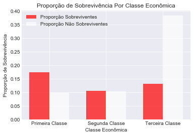

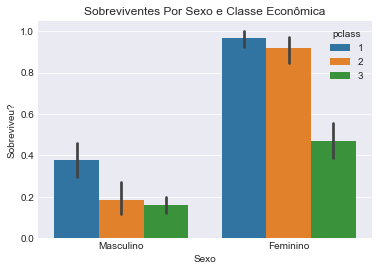

```python
pclass_analysis(custom_df)
```

Vale ressaltar, entretanto, que uma conclusão definitiva exige algum procedimento de inferência estatística.

#### Pergunta 4: O preço da passagem está relacionado à chance de sobrevivência? Em outras palavras, que características tinham as passagens de passageiros que sobreviveram?

Poderíamos nos perguntar também: existe correlação entre as três variáveis: classe, preço da passagem e taxa de sobrevivência?

```
Média do Valor da Passagem dos Passageiros que Sobreviveram: 50.326558566978186

Média do Valor da Passagem dos Passageiros que Não Sobreviveram: 24.09723026315788
```

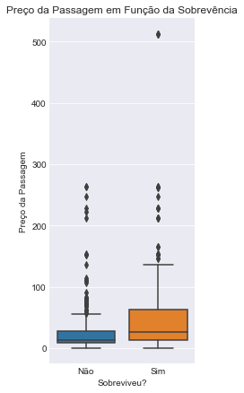

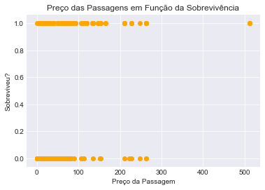

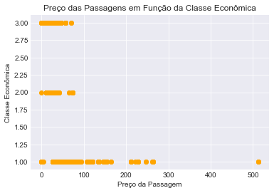

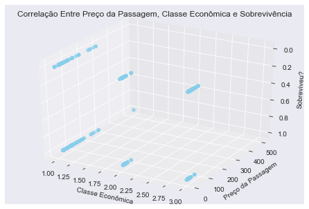

```python
fare_analysis(custom_df)
```

Analogamente à pergunta anterior, podemos perceber uma tendência de maior taixa de morte em pessoas que tinham passagens mais baratas.

O segundo gráfico de correlação mostra o comportamento que esperávamos: evidentemente, as classes econômicas maiores (1 e 2) possuem passagens mais caras.

O terceiro gráfico, em três dimensões, mostra as três variáveis em conjunto. O que podemos perceber deste gráfico é que a tendência se desloca em direção às pessoas que sobreviveram (sobrevivência = 1) quando a Classe Econômica é mais próxima de 1 e o preço da passagem mais próximo de 500, confirmando a forte sugestão de que pessoas com passagens mais baratas e, portanto, em classe econômicas inferiores foram mais prejudicas no acidente.

## Etapa 4: Conclusões

Primeiramente, é fundamental mencionar que como estamos apenas no escopo da Estatística Descritiva, não podemos realizar afirmações acertivas sobre nossas conclusões. Entretanto, conseguimos obter bons "insights" que poderiam ser validados posteriormente com ferramentes mais poderosas de análise.

Vamos analisar as conclusões tiradas individualmente para cada pergunta:

1) Pode-se afirmar que o gráfico de correlação sugere uma leve tendência de correlação positiva entre idade e número de mortos. Além disso, os demais gráficos apresentados sustentam essa afirmação: nitidamente o gráfico de dispersão da idade dos sobreviventes possui média inferior à do gráfico de dispersão da idade dos não sobreviventes. Além disso, nota-se que a dispersão da idade dos não sobreviventes é distorcida à direita, justamente a direção que representa aumento da idade. Vale ressaltar, entretanto, que não podemos afirmar de forma sólida que esta correlação positiva entre idade e número de sobreviventes de fato exista. A principal razão disso é o fato de, como explicado na etapa de Data Wrangle, o atributo "Idade" possuir muitos dados ausentes. Sendo assim, a amostra para esta característica possui poucos elementos, dificultando uma conclusão mais sólida.

2) Embora a tendência seja imaginar que pessoas com maior número de crianças ou casais foram mais mais afetados pelo acidente, os gráficos apresentados neste item não sustentam essa afirmação. Nitidamente, a média de crianças e casais entre os sobrevivente e os não sobreviventes é muito parecida. Além disso, os gráficos de contagem não mostram uma evolução do número de crianças e casais entre os que não sobreviveram. Pelo contrário, esse número se comporta de forma semelhante entre os que sobreviveram e os que não sobreviveram, sugerindo que não haja correlação. O gráfico de correlação, por sua vez, pode parecer indicar que exista sim correlação. Entretanto, sua análise não permite uma conclusão forte sem algum elemento inferencial que a reforce.

3) Podemos dizer que James Cameron foi justo em seu filme! De fato, todas as análises neste item sugerem que pessoas que estavam em classe econômica mais baixas (sendo a classe 3 a mais baixa) foram mais prejudicadas, ou seja, estavam em maior proporção entre os que morreram. Além disso, o segundo gráfico mostrado nesse item confirma essa tendência mesmo segregando as pessoas por gênero.

4) Conforme esperávamos, a classe econômica e o preço das passagens estão correlacionados, ou seja, pessoas em classes econômicas melhores dentro do navil (1 e 2) pagaram mais pela passagem. Consequentemente, o resultado deste item foi igual ao do item anterior: as pessoas com passagens mais baratas estavam em maior proporção entre os não sobreviventes e pessoas que pagaram mais pelas suas passagens estava em proporção maior entre os sobreviventes.

### 4.1 Limitações

Alguns fatores importantes ao se levantar uma amostra devem ser considerados (Neto, C.):

```
 - Garantir que a amostra seja representativa da população, ou seja, a amostra deve ter as mesmas características básicas da população no que diz respeito às variáveis que estão sendo pesquisadas.
 - É preciso garantir que as amostras sejam obtidas por processos adequados. Erros no momento da seleção das amostras comprometem todo o trabalho analítico.
 - Deve-se escolher o método de amostragem mais adequado a cada caso (Amostragem Probabilísitca ou Não Probabilistica).
```

Em nosso caso de estudo, estamos trabalhando com dados que nos foram previamente fornecidos. Sendo assim, evidentemente estamos sujeitos a estar trabalhando com dados com vícios de amostragem e que, portanto, não sejam representativos o suficiente da população.

Além disso, é importante considerar que quanto maior o tamanho da amostra, melhor será a estimação dos parâmetros bem como a capacidade de tirar conclusões analíticas. Em nosso caso especificamente, como vimos na etapa de Data Wrangle, o número de linhas repetidas era bastante grande e, particularmente para o atributo "Idade", o número de dados ausentes era enorme. A perda de dados é sem dúvida um dos fatores que afeta enormemente a análise, dificultado formular conclusões sólidas.

Particularmente neste projeto, essas limitações foram tratadas segregando-se o DataFrame em dois subconjuntos:

[output not shown]

### Referências Bibliográficas

Referências Utilziadas Sobre o Caso Titanic:  
https://pt.wikipedia.org/wiki/Titanic_(1997)  
https://pt.wikipedia.org/wiki/RMS_Titanic

Referências Utilizadas Para os Gráficos:  
https://seaborn.pydata.org/generated/seaborn.distplot.html  
https://seaborn.pydata.org/tutorial/categorical.html  
https://python-graph-gallery.com/370-3d-scatterplot/

Referências utilizadas para resolver dúvidas:  
https://stackoverflow.com/questions/36370839/better-way-to-drop-nan-rows-in-pandas  
https://stackoverflow.com/questions/29868091/boxplot-with-pandas-and-groupby  
https://stackoverflow.com/questions/40755680/how-to-reset-index-pandas-dataframe-after-dropna-pandas-dataframe

Livros Utilizados:  
COSTA NETO, P.L.O. Estatística. 3a Ed., São Paulo, Editora Blucher Ltda., 2002. 266 p